# KSN_prep

## Data Preparation:

**Data Augmentation:**

Create more data by applying transformations like rotations, flips, zooms, and shifts to existing images. This increases dataset size and diversity, improving the model's generalization.

**Normalization:**

Rescaling pixel values (e.g., from 0-255 to 0-1) helps the CNN converge faster and perform better by standardizing the input range.

**Class Imbalance Handling:**

If the dataset is unbalanced (e.g., more fighter-jet images than missile), techniques like oversampling the minority class or undersampling the majority class help avoid model bias.

**Cross-Validation:**

Perform cross-validation, where the dataset is split into multiple folds, ensuring that the model is evaluated across various subsets of the data, improving robustness.

**Shuffling Data:**

Shuffle the dataset before splitting to ensure random distribution of data across train, validation, and test sets. This prevents patterns in the data order from influencing model performance.

```python
import os
import numpy as np
import pandas as pd
import matplotlib.pyplot as plt
import shutil
import plotly.graph_objects as go
from sklearn.metrics import confusion_matrix, classification_report
import random
from tensorflow.keras.preprocessing import image
from tensorflow.keras.preprocessing.image import ImageDataGenerator
from tensorflow.keras.models import Sequential
from tensorflow.keras import layers
from tensorflow.keras import optimizers
from tensorflow.keras.callbacks import TensorBoard
from tensorflow.keras.applications import VGG19

np.set_printoptions(precision=6, suppress=True)
```

```python
base_dir = './data/planes'
raw_no_of_files = {}
classes = ['fighter-jet','missile', 'helicopter']
for dir in classes:
    raw_no_of_files[dir] = len(os.listdir(os.path.join(base_dir, dir)))

for folder_name in classes:
  raw_no_of_files[folder_name] = len(os.listdir(os.path.join(base_dir, folder_name)))

raw_no_of_files.items()
```

```
dict_items([('fighter-jet', 1867), ('missile', 1334), ('helicopter', 1387)])
```

**Setting up a structured directory hierarchy for organizing images into train, validation, and test datasets, with further subfolders for each class.**

```python
data_dir = './images'
if not os.path.exists(data_dir):
  os.mkdir(data_dir)

train_dir = os.path.join(data_dir, 'train')
valid_dir = os.path.join(data_dir, 'valid')
test_dir = os.path.join(data_dir, 'test')

train_fighter_dir = os.path.join(train_dir, 'fighter')
train_missile_dir = os.path.join(train_dir, 'missile')
train_helicopter_dir = os.path.join(train_dir, 'helicopter')

valid_fighter_dir = os.path.join(valid_dir, 'fighter')
valid_missile_dir = os.path.join(valid_dir, 'missile')
valid_helicopter_dir = os.path.join(valid_dir, 'helicopter')

test_fighter_dir = os.path.join(test_dir, 'fighter')
test_missile_dir = os.path.join(test_dir, 'missile')
test_helicopter_dir = os.path.join(test_dir, 'helicopter')

for dir in (train_dir, valid_dir, test_dir):
  if not os.path.exists(dir):
    os.mkdir(dir)

dirs = [train_fighter_dir, train_missile_dir, train_helicopter_dir,
        valid_fighter_dir, valid_missile_dir, valid_helicopter_dir,
        test_fighter_dir, test_missile_dir, test_helicopter_dir]

for dir in dirs:
  if not os.path.exists(dir):
    os.mkdir(dir)
```

```python
fighter_fnames = os.listdir(os.path.join(base_dir, 'fighter-jet'))
missile_fnames = os.listdir(os.path.join(base_dir, 'missile'))
helicopter_fnames = os.listdir(os.path.join(base_dir, 'helicopter'))

fighter_fnames = [fname for fname in fighter_fnames if fname.split('.')[1].lower() in ('jpg', 'jpeg', 'png')]
missile_fnames = [fname for fname in missile_fnames if fname.split('.')[1].lower() in ('jpg', 'jpeg', 'png')]
helicopter_fnames = [fname for fname in helicopter_fnames if fname.split('.')[1].lower() in ('jpg', 'jpeg', 'png')]
```

**Splitting Data:**

**Calculating the total number of images in each class and splits them into training (70%), validation (20%), and test (10%) sets.**

```python
size = min(len(fighter_fnames), len(missile_fnames), len(helicopter_fnames))


train_size = int(np.floor(0.7 * size))
valid_size = int(np.floor(0.2 * size))
test_size = size - train_size - valid_size

train_idx = train_size
valid_idx = train_size + valid_size
test_idx = train_size + valid_size + test_size
```

```python
for i, fname in enumerate(fighter_fnames):
  if i <= train_idx:
    src = os.path.join(base_dir, 'fighter-jet', fname)
    dst = os.path.join(train_fighter_dir, fname)
    shutil.copyfile(src, dst)
  elif train_idx < i <= valid_idx:
    src = os.path.join(base_dir, 'fighter-jet', fname)
    dst = os.path.join(valid_fighter_dir, fname)
    shutil.copyfile(src, dst)
  elif valid_idx < i < test_idx:
    src = os.path.join(base_dir, 'fighter-jet', fname)
    dst = os.path.join(test_fighter_dir, fname)
    shutil.copyfile(src, dst)

for i, fname in enumerate(missile_fnames):
  if i <= train_idx:
    src = os.path.join(base_dir, 'missile', fname)
    dst = os.path.join(train_missile_dir, fname)
    shutil.copyfile(src, dst)
  elif train_idx < i <=valid_idx:
    src = os.path.join(base_dir, 'missile', fname)
    dst = os.path.join(valid_missile_dir, fname)
    shutil.copyfile(src, dst)
  elif valid_idx < i < test_idx:
    src = os.path.join(base_dir, 'missile', fname)
    dst = os.path.join(test_missile_dir, fname)
    shutil.copyfile(src, dst)

for i, fname in enumerate(helicopter_fnames):
  if i <= train_idx:
    src = os.path.join(base_dir, 'helicopter', fname)
    dst = os.path.join(train_helicopter_dir, fname)
    shutil.copyfile(src, dst)
  elif train_idx < i <=valid_idx:
    src = os.path.join(base_dir, 'helicopter', fname)
    dst = os.path.join(valid_helicopter_dir, fname)
    shutil.copyfile(src, dst)
  elif valid_idx < i < test_idx:
    src = os.path.join(base_dir, 'helicopter', fname)
    dst = os.path.join(test_helicopter_dir, fname)
    shutil.copyfile(src, dst)
```

```python
print('fighter - zbiór treningowy', len(os.listdir(train_fighter_dir)))
print('fighter - zbiór walidacyjny', len(os.listdir(valid_fighter_dir)))
print('fighter - zbiór testowy', len(os.listdir(test_fighter_dir)))

print('missile - zbiór treningowy', len(os.listdir(train_missile_dir)))
print('missile - zbiór walidacyjny', len(os.listdir(valid_missile_dir)))
print('missile - zbiór testowy', len(os.listdir(test_missile_dir)))

print('helicopter - zbiór treningowy', len(os.listdir(train_helicopter_dir)))
print('helicopter - zbiór walidacyjny', len(os.listdir(valid_helicopter_dir)))
print('helicopter - zbiór testowy', len(os.listdir(test_helicopter_dir)))
```

```
fighter - zbiór treningowy 921
fighter - zbiór walidacyjny 263
fighter - zbiór testowy 124
missile - zbiór treningowy 921
missile - zbiór walidacyjny 263
missile - zbiór testowy 97
helicopter - zbiór treningowy 921
helicopter - zbiór walidacyjny 263
helicopter - zbiór testowy 130
```

## Data exploration

```
(-0.5, 1599.5, 991.5, -0.5)
```

[figure not shown]

```python
idx = 220 #@param {type:'slider', min:0, max:919}
names_mapping = dict(enumerate(fighter_fnames))
img_path = os.path.join(train_fighter_dir, names_mapping[idx])

img = image.load_img(img_path)

plt.figure(figsize=(10, 10))
plt.imshow(img)
plt.grid(False)
plt.axis(False)
```

```
(-0.5, 799.5, 534.5, -0.5)
```

[figure not shown]

```python
idx = 147 #@param {type:'slider', min:0, max:919}
names_mapping = dict(enumerate(helicopter_fnames))
img_path = os.path.join(train_helicopter_dir, names_mapping[idx])

img = image.load_img(img_path)

plt.figure(figsize=(10, 10))
plt.imshow(img)
plt.grid(False)
plt.axis(False)
```

## Data Augmentation (train_datagen):

Various transformations are applied to the training images to artificially increase the diversity of the training dataset. These include:

- rotation_range: Rotating images randomly by up to 45 degrees.
- rescale: Scaling pixel values to the range [0, 1] by dividing by 255.
- width_shift_range & height_shift_range: Randomly shifting images horizontally and vertically by up to 25%.
- shear_range: Randomly applying a shear transformation (like slanting) by 30%.
- zoom_range: Randomly zooming in/out on the images by up to 30%.
- horizontal_flip: Randomly flipping the image horizontally.
- fill_mode: Filling in any missing pixels created by transformations using the nearest pixel values.

**Rescaling for Validation (valid_datagen):**

No augmentations are applied to validation data. The images are simply rescaled by dividing pixel values by 255, ensuring they are normalized.

**Creating Generators (train_generator and valid_generator):**

These generators load images from directories (train_dir and valid_dir), resize them to 150x150 pixels, and generate batches of 32 images at a time. The class_mode='categorical' option indicates that the model will be used for multi-class classification. This setup enables the model to learn from augmented training data while using the validation data only for evaluation without transformations.

```python
train_datagen = ImageDataGenerator(
    rotation_range=45,
    rescale=1./255.,
    width_shift_range=0.25,
    height_shift_range=0.25,
    shear_range=0.3,
    zoom_range=0.3,
    horizontal_flip=True,
    fill_mode='nearest'
)


valid_datagen = ImageDataGenerator(rescale=1./255.)

train_generator = train_datagen.flow_from_directory(directory=train_dir,
                                                   target_size=(150, 150),
                                                   batch_size=32,
                                                   class_mode='categorical')

valid_generator = valid_datagen.flow_from_directory(directory=valid_dir,
                                                   target_size=(150, 150),
                                                   batch_size=32,
                                                   class_mode='categorical')
```

```
Found 2763 images belonging to 3 classes.
Found 789 images belonging to 3 classes.
```

```python
def display_augmented_images(directory, idx):
    fnames = [os.path.join(directory, fname) for fname in os.listdir(directory)]
    img_path = fnames[idx]
    img = image.load_img(img_path, target_size=(150, 150))

    x = image.img_to_array(img)
    x = x.reshape((1, ) + x.shape)

    i = 1
    plt.figure(figsize=(16, 8))
    for batch in train_datagen.flow(x, batch_size=1):
        plt.subplot(3, 4, i)
        plt.grid(False)
        imgplot = plt.imshow(image.array_to_img(batch[0]))
        i += 1
        if i % 13 == 0:
            break
```

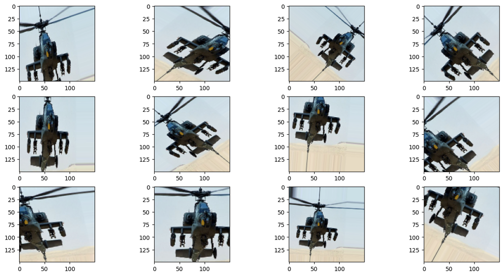

```python
#@title Zbiór treningowy drone:
idx = 46 #@param {type:'slider', min:0, max:919}

# train_passenger_dir
# train_drone_dir
display_augmented_images(train_helicopter_dir, idx)
```